# The Student Sip Study: Observing UOA Student Drink Choices & Study Behaviors

# Water Consumption Patterns

## What are the most common time in the day that water is consumed the most?

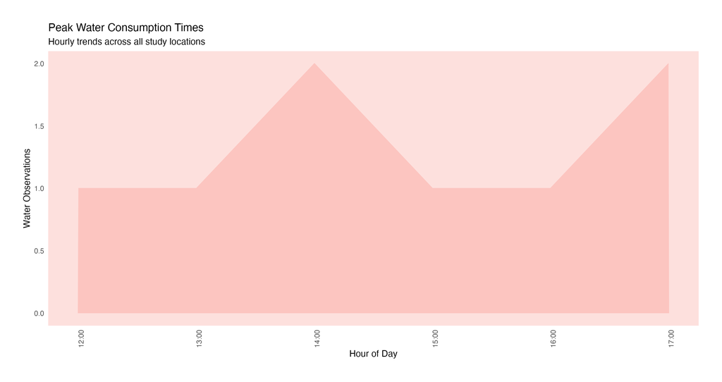

12:00–13:00: Water intake remains steady with just 1 observation, indicating that students may be finishing lunch or transitioning between classes without a strong focus on hydration.

14:00: A sudden increase to 2 observations suggests a post-lunch hydration boost, as students might be refilling their water bottles before afternoon lectures or settling into study sessions.

15:00–16:00: The drop back to 1 observation indicates a dip, possibly because students are immersed in their coursework or choosing other beverages like coffee to combat midday fatigue.

17:00: The final spike to 2 observations could be linked to students getting ready for evening activities—rehydrating after classes, going to the gym, or grabbing water before heading home.